# Extra Practice Test — Logistic Regression

matthias.kuhn@tu-dresden.de

February 1, 2024 <sub>[8bca23a]</sub>

**(solutions interspersed)**

The crash of the NASA space shuttle Challenger on January 28th 1986 was linked to failure of O-ring seals in the rocket engines. A later investigation found that — due to the cold temperatures at the time of launch and the possible presence of frozen water in the solid rocket motor joints — the O-rings were too slow in returning to their correct shape. This complete failure led to the explosion.

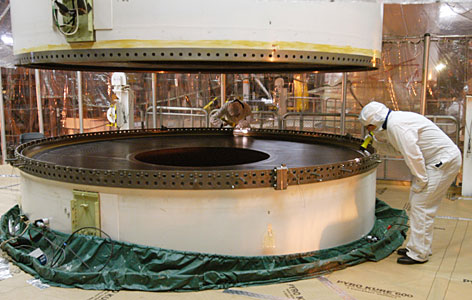

O-ring from NASA space shuttle Endeavor

### Data

Retrospectively, data on O-ring failures was collected on the `n=23` previous shuttle missions. Load the dataset from the CSV-file `orings.csv` into your R-session and view it in RStudio.

- The numeric column `damage` numbers the observed damage incidents at `m=6` well-defined spots at the O-rings. Only when *all* six spots are damaged a complete failure with catastrophic consequences is triggered.
- The numeric column `temp` records the temperature at shuttle launch in degree Fahrenheit (°F).

### Logistic model fit

A logistic regression models the probability of a binary outcome depending on predictor variables.

Fit a simple logistic regression model with complete O-ring failure as outcome and `temp` as sole predictor variable, using the standard logit link function.

1. What is the estimated coefficient value for predictor `temp`?
2. Give an interpretation for this coefficient estimate.
3. The model summary shows the so-called Wald z-test for the coefficient `temp`. What is the underlying null hypothesis H<sub>0</sub> to the given P-value?
4. Use the residual deviance of this logistic regression model fit to judge how well the model fits: The residual deviance is approximately χ<sup>2</sup>-distributed with n-2 = 21 degrees of freedom under the null hypothesis H<sub>0</sub> that the concretely specified model fits the underlying data generating process. This approximation works as long as the general logistic model assumptions (e.g., response variable is truly binomial and link function is correct) hold and when the number of spots `m` is not too small. Provided all this, what is this P-value and based thereon, would you reject this model fit? The R-functions `deviance` and `df.residual` help you extract the relevant information from the model fit object.
5. The launch temperature on the day of the Challenger crash was just below freeze point with 31°F. What probability of complete O-ring failure is predicted by the model?

**Solution**

We fit a simple logistic regression fit with standard logit-link in R via `glm`. The summary shows the coefficient estimates and some more information on the model fit.

```r
fm <- glm(cbind(damage, 6-damage) ~ temp, family = binomial, data = orings)
summary(fm)
```

```
##
## Call:
## glm(formula = cbind(damage, 6 - damage) ~ temp, family = binomial,
##     data = orings)
##
## Coefficients:
##             Estimate Std. Error z value Pr(>|z|)
## (Intercept)  11.6630     3.2963    3.54   0.0004
## temp         -0.2162     0.0532   -4.07 0.000048
##
## (Dispersion parameter for binomial family taken to be 1)
##
##     Null deviance: 38.898  on 22  degrees of freedom
## Residual deviance: 16.912  on 21  degrees of freedom
## AIC: 33.67
##
## Number of Fisher Scoring iterations: 6
```

1. The coefficient of `temp` in the model is estimated as -0.21623.
2. The coefficient has a negative sign. Hence, an increase in temperature is predicted to decrease the chance for complete failure. We can estimate the odds ratio by exponentiating the coefficient:

```r
exp(coef(fm)["temp"])
```

```
##    temp
## 0.80555
```

In other words, the model predicts that an increase by one °F lowers the odds of complete failure by 19.45%.

3. The null hypothesis of the Wald test is that the true coefficient β<sub>temp</sub> is 0. $H_0: β_\text{temp} = 0$. The P-value here is 0.0000478. We would reject H<sub>0</sub> on the conventional significance level α=5%.
4. We calculate the P-value of the goodness of fit test using the χ<sup>2</sup>-distribution:

```r
pchisq(q = deviance(fm), df = df.residual(fm), lower.tail = FALSE)
```

```
## [1] 0.71641
```

The P-value is large. So, we have *no* reason to reject the null hypothesis that the model fits well. However, this is not proof that this model is correct. A different/simpler model might also fit adequately.

5. We use the model to predict the complete failure probability at `temp=31`. We can calculate the model prediction by hand, starting from the model coefficients to get the logits and from there to finally get the odds and the corresponding probability:

```r
fail_t31_logit <- coef(fm)[[1]] + 31 * coef(fm)[[2]]
fail_t31_odds <- exp(fail_t31_logit)
fail_t31_prob <- fail_t31_odds / (fail_t31_odds + 1)
fail_t31_prob
```

```
## [1] 0.99303
```

**Or,** we can let the R-function `predict` do the job for us:

```r
fail_t31_prob <- as.vector(predict(fm, newdata = data.frame(temp = 31), type = "response"))
fail_t31_prob
```

```
## [1] 0.99303
```

So, we see that the model predicts a very high probability for complete failure. If this was known before, the start and subsequent crash of the shuttle could have been prevented.

But, we need to acknowledge that the model prediction is quite an extrapolation as the data from the sample is solely on higher temperatures. The single observation at temperature 53°F in the sample has also an alarmingly high leverage on the model fit.

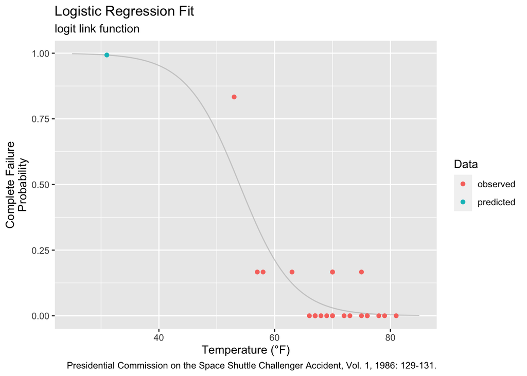

```r
library("ggplot2")
orings2 <- orings |>
  dplyr::mutate(damageProp = damage/6, type = "observed") |>
  dplyr::add_row(temp = 31, damageProp = fail_t31_prob, damage = damageProp * 6, type = "predicted")

ggplot(data = orings2, mapping = aes(x = temp, y = damageProp)) +
  geom_function(fun = \(x) stats::plogis(q = coef(fm)[1] + x * coef(fm)[2]), col = "grey", alpha = .7) +
  geom_point(mapping = aes(col = type)) +
  xlim(25, 85) + labs(col = "Data", x = "Temperature (°F)", y = "Complete Failure\nProbability",
                      title = "Logistic Regression Fit", subtitle = "logit link function",
                      caption = "Presidential Commission on the Space Shuttle Challenger Accident, Vol. 1, 1986: 129-131.")
```